# Graphical Exploratory Data Analysis (GEDA)

## Datos de CONAGUA

#### Arciga, Yusuri., López, Carlos., Tejada, Laura. & Villalobos, Elena.

El presente trabajo tiene como objetivo realizar el Análisis Exploratorio Gráfico de la base de datos del consumo de agua de la Ciudad de México. Este trabajo nos proporcionará una idea general sobre el contexto y alcance de la información contenida en esta base datos para desarrollar, en el futuro, un modelo de predicción del Índice de Desarrollo contenida en la misma base.

### Características generales de la base

Esta base de datos contiene información de los medidores de consumo de agua, instalados o autorizados por el Sistema de Aguas. Tenemos **71102 observaciones** y **17 variables**.

Se tienen dos mediciones principales del consumo de agua:

- `consumo_total`: Que es el consumo total de acuerdo a los medidores instalados o autorizados por el Sistema de Aguas.
- `comsumo_prom`: Que es un cálculo promedio de consumo de agua que se aplica para cubrir las faltas o fallas en los aparatos de medición.

Para el consumo de agua existen diferentes tipos de uso que tendrán su respectiva medición de consumo total y promedio:

- Doméstico: Uso habitacional (`consumo_prom_dom`, `consumo_total_dom`).
- No Doméstico: Uso no doméstico (`consumo_prom_no_dom`, `consumo_total_no_dom`).
- Mixto: uso doméstico y no doméstico (`consumo_total_mixto`, `consumo_prom_mixto`).

Todas las varibles antes mencionadas son numéricas y están en $m^3$.

Adicional esta base tiene información de geolocalización:

- `alcaldía`: Variable categórica que contiene las 16 alcaldías de la CDMX.
- `colonia`: Variable categórica que contiene 1340 colonias registradas.
- `latitud` y `longitud`: Variables numéricas que representan las coordenadas de los medidores.

La información temporal del consumo de agua es:

- `bimestre`: que contiene la información de solo tres bimestres.
- `anio`: que es solo tiene la información del año 2019.

Adicionalmente, tiene información que diferencía territorialmente a la población de la CDMX de acuerdo a su nivel de desarrollo económico (`indice_des`), agregando la información por colonia, los niveles son:

- POPULAR: Niveles de desarrollo más bajos de la Ciudad.
- BAJO: Niveles de desarrollo bajo de la Ciudad.
- MEDIO: Niveles de desarrollo medio de la Ciudad.
- ALTO: Niveles de desarrollo altos de la Ciudad.

La base también contiene las variables de `nomgeo` y `gid`, la primera hace referencia a la misma información de alcaldía, y la segunda no encontramos referencia de qué tipo de información representa esta variable. Estas, dos últimas variables no se tomarán en cuenta en el siguiente análisis.

Para completar el presente análisis se utilizó la información del número de `habitantes` por alcaldía, extraída del INEGI.

## 1. Consumo de agua

Primero queremos tener información sobre todas las variables que tenemos de consumo de agua:

A continuación haremos un análisis general de las variables con las que contamos para después enfocarnos a las que nos pueden aportar información que podemos considerar más valiosa.

#### Variables de consumo total

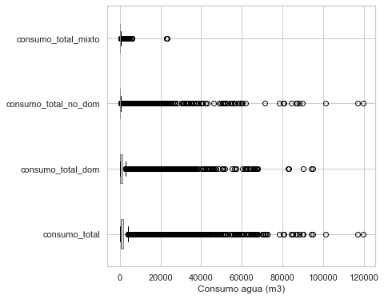

#### Variables de consumo promedio

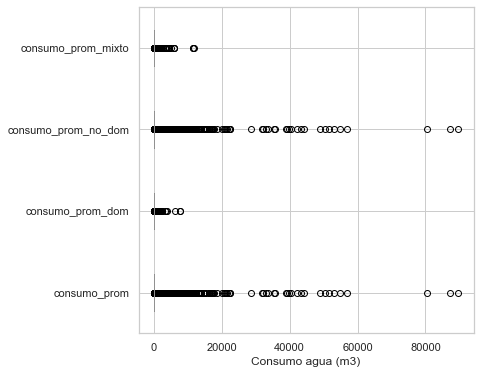

Como se observa en tanto en las mediciones de agua totales como promedio existen demasiados outliers, por lo que las cajas no se podrán apreciar de manera clara. Ahora observaremos el comportamiento de estas variables sin tomar en cuenta los outliers.

#### Variables de consumo total sin outliers

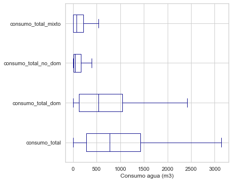

En este gráfico se puede apreciar más claramente la distribución de los valores en el consumo total de agua, así como de los tipos de consumo. Se observa que el consumo total de agua tiene un comportamiento similar al de consumo total doméstico. En cuanto al consumo total mixto y no doméstico, tienen mucho menos m3 de ocupación de agua y tienen comportamientos similares.

#### Variables de consumo promedio sin outliers

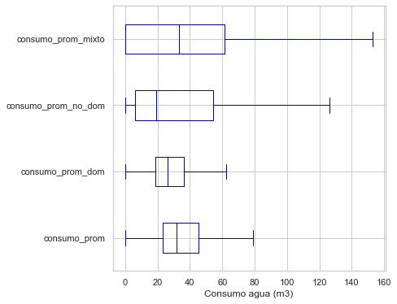

Como se observa en ambos gráficos de consumo promedio de agua va en un rango no tan alto como el de consumo total. Uno esperaría que si son promedios estarían en un rango de 0 a 1, o de 0 a 100, pero a pesar de que muchos de los valores se encuentran entre esos rangos, tenemos muchos outliers que sobre pasan esa medida. Por lo tanto surge la duda de exactamente cómo se están calculando esas medidas. Ya que analizamos las variables de consumo de agua de manera individual, ahora analizaremos las otras variables categóricas de manera individual.

## 2. Alcaldías, bimestres e Índices de desarrollo.

#### Conteo de información por alcaldía

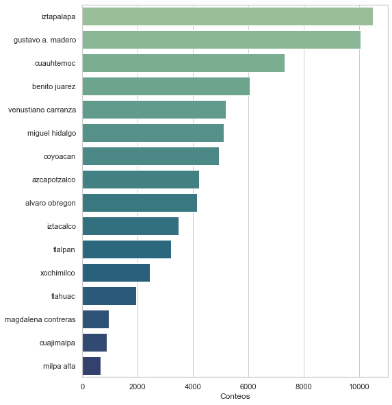

Notablemente tenemos más información en Iztapalaba y Gustavo A. Madero, mientras que de las alcaldías en las que tenemos menos conteos están la Magdalena Contreras, Cuajimalpa y Milpa Alta. Ésto podría ser un indicador de qué alcaldías son las que consumen más agua pero continuarémos con análisis para poder llegar a una conclusión.

#### Conteo de información por bimestre

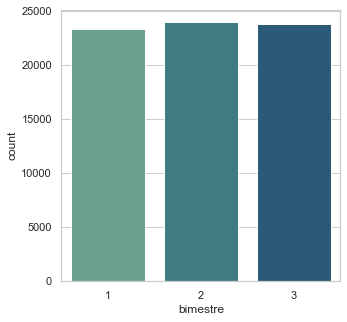

Observamos que los conteos por bimestre son muy similares entre ellos, la diferencia es mínima pero en el primer bimestre tenemos un poco menos de información.

#### Conteo de información por índice de desarrollo

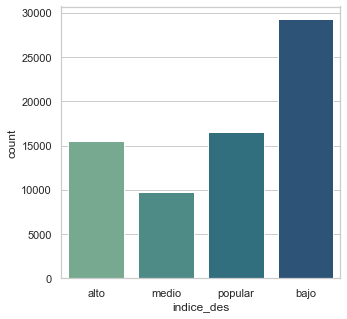

Observamos que el índice de desarrollo más común es el bajo que casi es el doble del índice de desarrollo popular. Ésta última categoría tiene casi el mísmo número de conteos que alto. La categoría de medio es la que tiene menos mediciones.

Lo que nos indica que los índices de desarrollo en la Ciudad de México siguen una tendencia hacía ser bajos, aún siendo considerado como el estado de la república que tiene el mayor desarrollo en el país.

A continuación presentaremos gráficos de acuerdo a diversas preguntas planteadas.

## 3. Relación entre los consumos de agua de acuerdo al tipo de uso en las alcaldías.

Sabemos que `consumo_total` contiene una cantidad considerable de outliers, por lo que para observar el comportamiento de tendencia, tomaremos los valores de la base que están en un rango más considerable. Para poder trabajar con menos outliers calculamos el quantil al 90%, es decir, quitamos el 10% de la información.

```
3643.601000000001
```

```
63991
```

Vamos a trabajar con 63991 datos después de haber quitado algunos outliers.

#### Tipo de consumo total por alcaldía

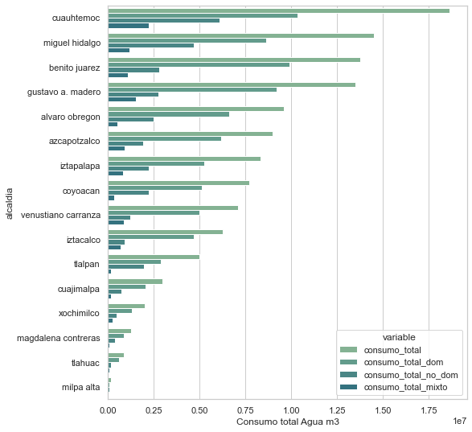

De principio se observa que la alcaldía Cuauhtémoc tiene mayor consumo de agua, tanto en consumo de agua total como en consumo de agua de tipo doméstico. La alcaldía que no sigue el patrón de decrecimiento entre consumo total y consumo doméstico es Miguel Hidalgo que tiene menos proporción de consumo doméstico que Benito Juárez.

Las demás tienen un comportamiento similar. Algo importante que mencionar es que habíamos observado anteriormente que la alcaldía Iztapalapa tiene más mediciones que las demás alcaldías, sin embargo, no tiene el consumo más alto como se hubiera esperado.

#### Diferencias de consumo entre el doméstico y no doméstico por alcaldía

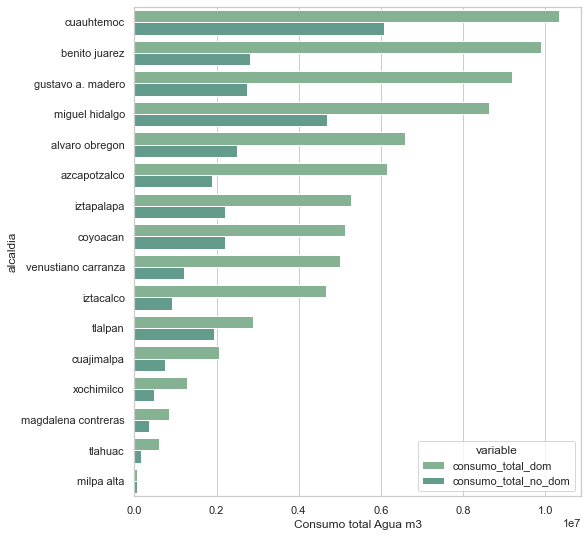

Es claro que existe un mayor consumo de agua para el uso doméstico y que en la mayoría de los casos el no doméstico se encuentra al rededor de la mitad o menos.

Las alcaldías que lideran el consumo de agua de uso doméstico son la Cuauhtémoc, Benito Juárez y Gustavo A. Madero.

Las alcaldías que tienen un mayor consumo no doméstico son la Cuauhtémoc, Miguel Hidalgo y Benito Juárez.

Podemos cuestionarnos la definición exacta de uso doméstico o qué engloba pues si se incluyen las oficinas o corporativos en el uso no doméstico tiene sentido que la delegación Miguel Hidalgo esté en el top 3 pues ahí se concentran la mayoría de éstos.

#### Tipo de consumo promedio por alcaldía

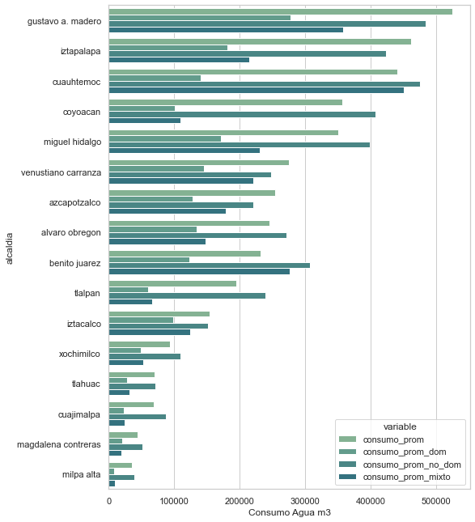

En cuanto al consumo promedio de las alcaldías cambia en gran medida pues se supone que esta es una estimación promedio del consumo de agua donde no se tienen registros por fallas o faltas de medidores. Lo más notorio de observar en estos gráficos es que Iztapalapa sube en consumo promedio, y en consumo promedio no doméstico. Esto sucede manera similar para Gustavo A. Madero. En todas las delegaciones parece incrementar mucho el consumo promedio no doméstico y mixto.

## 4. Relación entre el índice de desarrollo, la alcaldía y el consumo de agua

#### Consumo total por alcaldía y su índice de desarrollo

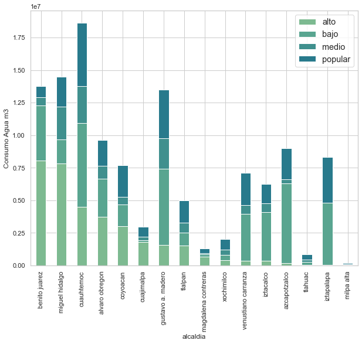

Por otro lado, Cuauhtemoc tiene una dispercsión similiar para cada tipo de indice de desarrollo, mostrando un cantidad igualmente distribuida de indice alto, bajo y popular. Mientras que las demás alcaldías muestran una distribución entre los indices de desarrollo menos homogénia.

#### Consumo total porcentual por alcaldía y su índice de desarrollo

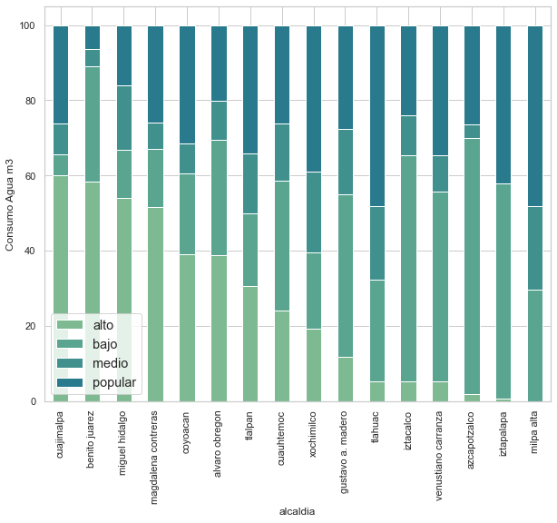

Al graficar de esta manera (porcentualmente), nos permite una mejor visualización de las proporciones que existen en alcaldías donde la cantidad de datos es pequeña, mostrando la verdadera distribución que existe en las alcaldía del indice de desarrollo. Esto nos permitirá hacer un análisis más detallado del gasto de agua según la dispersión del indice de desarrollo.

Cómo vemos, las proporciones de indice de desarrollo alto, cómo esperábamos se mantienen el las alcaldías de Benito Juárez, Miguel Hidalgo. Pero un detalle interesante que nos permite ver este grafico es que el gasto de agua para el indice de desarrollo alto en Magdalena Contreras es mayor a los otros tres.

#### Consumo pormedio y su relación con el índice de desarrollo

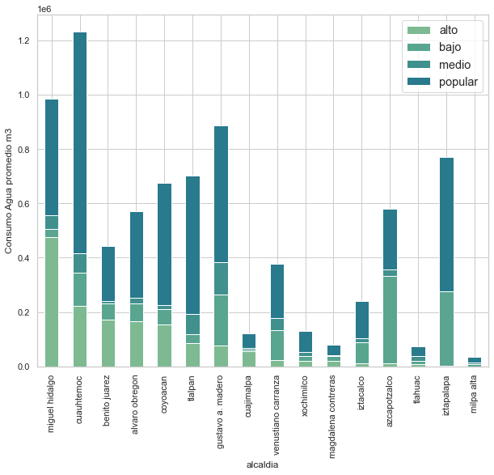

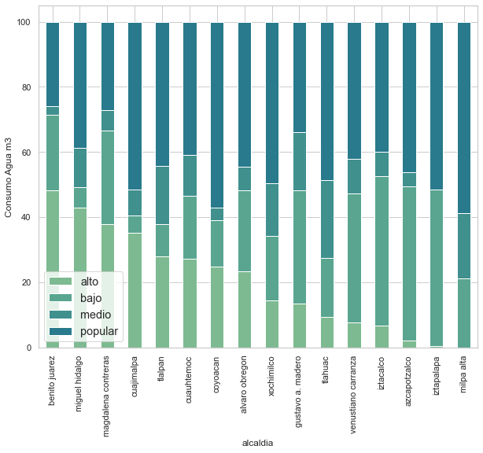

#### Consumo porcentual total de cada alcaldía por bimestre

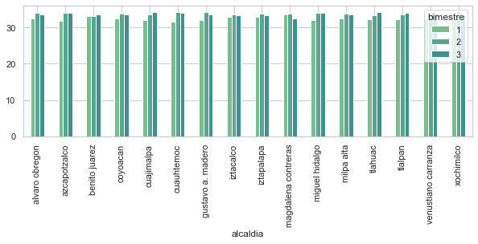

El consumo que muestra cada alcaldía por bimestre es muy similar, a excepción de la alcaldía Magdalena Contreras, todas las demás muestran un patrón ascendente de el primero hacia los siguientes bimestres.

Por esta similitud entre barras podemos saber, que después del primer bimestre de 2019 el consumo fue ligeramente mayor en la Ciudad de México.

## 5. Análisis de latitud y longitud de acuerdo al Índice de Desarrollo

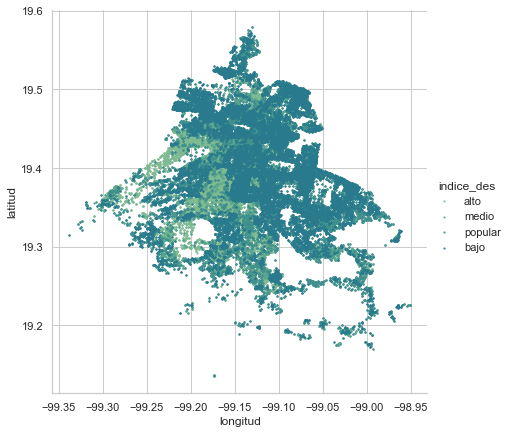

En este gráfico podemos apreciar la distribución de los datos por alcaldía. Casi todos los datos con los que contamos son de la parte centro y norte de la Ciudad.

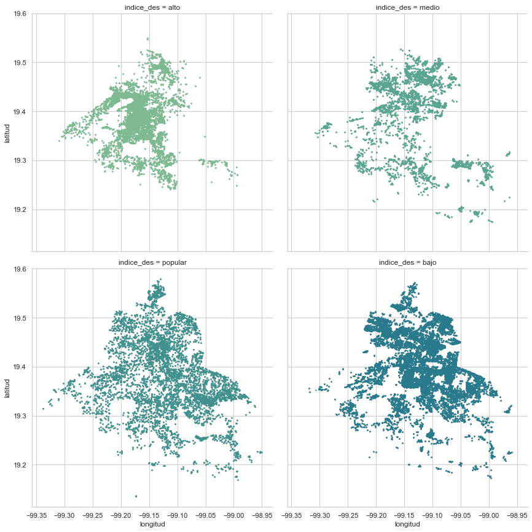

Aquí podemos observar la distribución de los datos geográficos, divididos por indice de desarrollo.

Los puntos de indice de desarrollo alto se muestran principalmente en el centro de la ciudad. Por otro lado, para los indices medio y popular muestran una distribución más homogénea en la ciudad. Y finalmente los datos relacionados a índice de desarrollo bajo se muestran cargados hacia el oriente de la ciudad.

## 6. Verificar si entidades con mayor densidad de habitantes consumen más agua.

Una primera gráfica sería el gasto de agua per cápita por alcaldia. Otras serían a mayor poblacion más gasto domestico. ¿Y qué tal el gasto no domestico

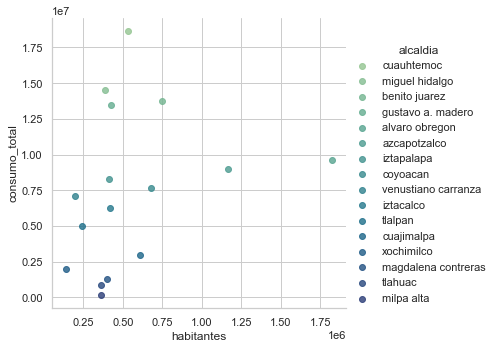

Los datos de habitantes por alcaldia fueron tomados del senso realizado por el inegi en 2015, que son los datos que le corresponden al dataset con el que estamos trabajando.

Como vemos, los datos no presentan relación alguna, lo que nos no dice que no existe algun nexo entre el numero de habitantes con el consumo total por alcaldia.

¿Y entre consumo domestico total y población existe alguna relación?

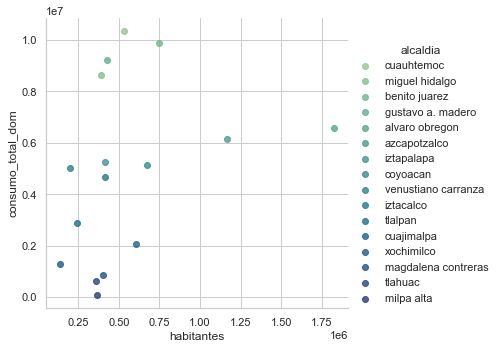

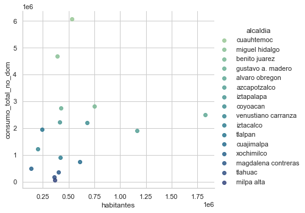

## 7. Valores Faltantes

Todos los registros para los que tenemos valores faltantes corresponden únicamente al primer bimestre de 2019. Además, esta falta de información solamente ocurre para cuatro de las variables, todas referentes al nivel de consumo de agua:

- Consumo total mixto
- Consumo total domiciliado
- Consumo promedio mixto
- Consumo promedio domiciliado

  En la siguiente gráfica se observa el volumen de valores nulos para el primer bimestre para las variables indicadas, para cada una de las alcaldías. En todos los casos, Iztapalapa encabeza esta lista, mostrando una falta de información de hasta 600 registros. Lo siguen Coyoacán, Gustavo A. Madero y Tlalpan, con una cantidad significativamente menor de valores faltantes, pero con un volumen alto comparado con el resto de las alcaldías.

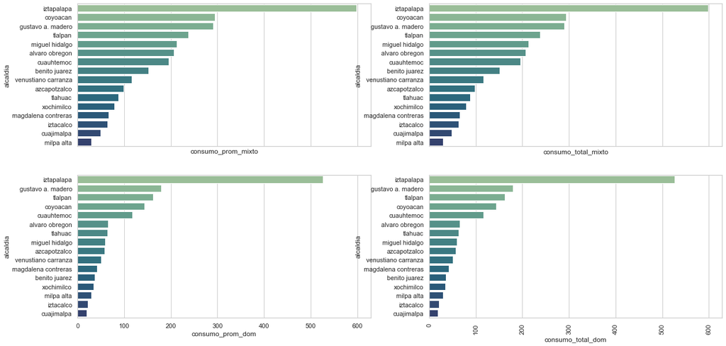

Considerando que los valores faltantes corresponden todos a un mismo periodo de tiempo y a menos de una cuarta parte de las variables del data set, es importante considerar si hubo pérdidas de información durante la transferencia de datos, o si el comportamiento descrito anteriormente corresponde a un comportamiento natural para el negocio.

Por otro lado, a pesar de que el volumen de valores faltantes es importante para identificar deficiencias en los datos, posibles errores en la transferencia y el desbalance en las variables categóricas que se utilizarán para el modelo, recordemos que éste desbalance en la información no existe solamente para los valores faltantes, sino que, como se comentó anteriormente, tenemos notablemente más registors para algunas alcaldías que para otras.

Por lo anterior, vale la pena considerar el porcentaje de valores faltantes por alcaldía, calculados como el número de valores faltantes dividido entre el número de registros por alcaldía:

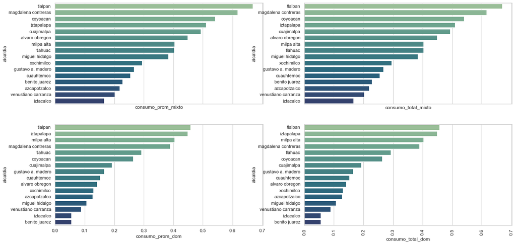

El orden de las alcaldías se reacomoda en estas últimas gráficas. Iztapalapa, que parecía tener carencias graves en la información, ya no parece tener tanta severidad como la que muestra Tlalpan, que ha perdido alrededor del 70% de la información respecto al consumo mixto, y el 45% respecto al consumo domiciliado. Así mismo, otra alcaldía que debería de preocuparnos es Milpa Alta, estando entre los primeros lugares en porcentaje de valores faltantes, y siendo además la alcaldía para la cual se cuenta con menos información.